# ANOVA de medidas repetidas

**Universidade Estadual de Maringá - Modelos Mistos**

- Aluno: Arthur Cesar Rocha
- Professora: Isolde Previdelli

## Objetivo

Replicar a análise vista em sala de aula para os dados de tratamento de pressão alta.

## Dados

- Pacotes

```r
library(dplyr) # Manipulação
library(tidyr) # Manipulação
library(magrittr) # Manipulação
library(broom)    # Manipulação
library(nlme)     # Modelo misto
```

- Leitura e transformação

Antes de mais nada é preciso transformar os dados do formato **wide** para **long**.

```r
dados=read.table(header=T,text = "
              Subject Baseline Placebo Trt_A Trt_B
              01 113 108 98 103
              02 108 110 96 104
              03 110 106 110 107
              04 99 98 78 88
              05 114 114 112 105
              06 109 103 88 97
              07 113 110 106 103
              08 112 108 99 108
              09 121 111 96 115
              10 98 103 98 107
              11 107 104 98 100
              12 123 117 97 103
              13 112 109 108 114
              14 96 94 99 97
              15 108 106 101 101
              16 111 99 102 87
              17 124 130 121 124
              18 113 119 101 114
              19 106 99 89 90
              20 99 94 85 59")

dados<-gather(dados,key = "Tratamento",
       value ="Pressão", -Subject)

dados$Tratamento = factor(dados$Tratamento)
dados$Subject = factor(dados$Subject)
```

## Análise

- Para todos os casos a variável resposta é **Pressão**

### ANOVA one-way

Neste caso supõe-se independência das observações, além da distribuição aproximadamente normal. Assumindo um modelo da forma:

$$y_{ij}=\mu + \tau_j + \epsilon_{ij}$$

```r
dados%$%
aov(Pressão ~ Tratamento) %>%
tidy %>%
knitr::kable()
```

| term | df | sumsq | meansq | statistic | p.value |
| --- | --- | --- | --- | --- | --- |
| Tratamento | 3 | 1482.55 | 494.1833 | 4.747558 | 0.0043462 |
| Residuals | 76 | 7911.00 | 104.0921 | NA | NA |

Foi possível observar significância no tratamento ($\alpha=0,05$) a partir desse método.

- Post-hoc (Tukey)

Para verificar quais médias diferem, fez-se um teste de Tukey para comparações múltiplas.

```r
dados%$%
aov(Pressão ~ Tratamento) %>%
TukeyHSD() %>%
 tidy() %>%
 knitr::kable()
```

| term | comparison | estimate | conf.low | conf.high | adj.p.value |
| --- | --- | --- | --- | --- | --- |
| Tratamento | Placebo-Baseline | -2.7 | -11.174915 | 5.7749152 | 0.8367389 |
| Tratamento | Trt_A-Baseline | -10.7 | -19.174915 | -2.2250848 | 0.0074935 |
| Tratamento | Trt_B-Baseline | -8.5 | -16.974915 | -0.0250848 | 0.0490457 |
| Tratamento | Trt_A-Placebo | -8.0 | -16.474915 | 0.4749152 | 0.0713013 |
| Tratamento | Trt_B-Placebo | -5.8 | -14.274915 | 2.6749152 | 0.2824308 |
| Tratamento | Trt_B-Trt_A | 2.2 | -6.274915 | 10.6749152 | 0.9036797 |

Aqui é possível interpretar a 5% de significância que os tratamentos A e B diferem do baseline, porém não diferem do placebo. Também é visível que esses dois tratamentos não diferem entre si, da mesma forma que o baseline não difere do placebo.

### ANOVA com blocos (two-way)

Uma das formas de separar a variabilidade de cada indivíduo é assumindo cada um deles como bloco no delineamento, ficando com um modelo da forma:

$$y_{ij}=\mu + \tau_j + \beta_i + \epsilon_{ij}$$

```r
dados%$%
aov(Pressão ~ Tratamento + Subject) %>%
tidy %>%          #transforma em dataframe
knitr::kable()    #faz tabela html
```

| term | df | sumsq | meansq | statistic | p.value |
| --- | --- | --- | --- | --- | --- |
| Tratamento | 3 | 1482.55 | 494.18333 | 13.296726 | 1.1e-06 |
| Subject | 19 | 5792.55 | 304.87105 | 8.203002 | 0.0e+00 |
| Residuals | 57 | 2118.45 | 37.16579 | NA | NA |

Os resultados dessa análise de variância são similares ao anterior, havendo significância para o tratamento, considerando $\alpha =$ 5% , também é visível que foi atribuida uma parte grande da variância residual para os indivíduos, indicando que são importantes na análise.

- Post-hoc (Tukey)

```r
dados%$%
aov(Pressão ~ Tratamento + Subject) %>%
TukeyHSD(which = "Tratamento") %>%
tidy %>%
knitr::kable()
```

[output not shown]

### ANOVA para medidas repetidas (one-way)

Esse método considera uma estrutura de covariância no delineamento, na forma de simetria composta, isto é, a matiz de covariância / correlação tem valores constantes iguais. No mais é similar ao caso anterior, em que a soma de quadrado é decomposta entre e dentre os indivíduos.

```r
dados %$%
aov(Pressão ~ Tratamento + Error(Subject/Tratamento)) %>%
summary
```

```
##
## Error: Subject
##           Df Sum Sq Mean Sq F value Pr(>F)
## Residuals 19   5793   304.9
##
## Error: Subject:Tratamento
##            Df Sum Sq Mean Sq F value   Pr(>F)
## Tratamento  3   1482   494.2    13.3 1.09e-06 ***
## Residuals  57   2118    37.2
## ---
## Signif. codes:  0 '***' 0.001 '**' 0.01 '*' 0.05 '.' 0.1 ' ' 1
```

O resultado é análogo, tendo significância de tratamento considerando $\alpha=5%$.

### Teste de Friedman (não paramétrico)

É possível abordar o problema de um ponto de vista não paramétrico, utilizando o teste de Friedman e seu post-hoc.

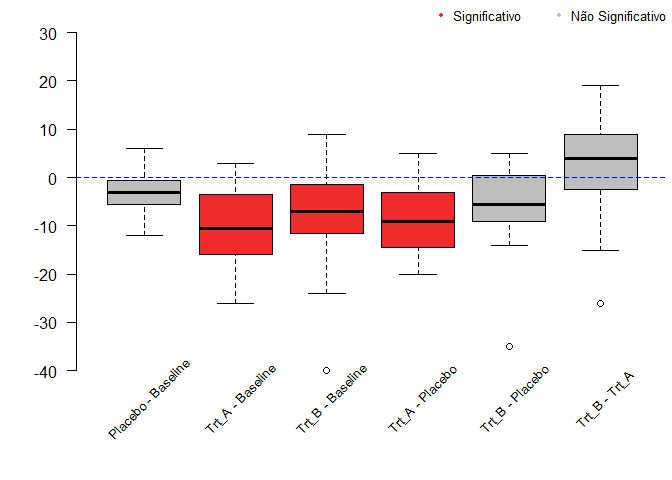

```
## $Friedman.Test
##
##  Asymptotic General Symmetry Test
##
## data:  Pressão by
##   Tratamento (Baseline, Placebo, Trt_A, Trt_B)
##   stratified by Subject
## maxT = 4.6633, p-value = 1.747e-05
## alternative hypothesis: two.sided
##
##
## $PostHoc.Test
##
## Placebo - Baseline 0.3692
## Trt_A - Baseline   0.0000
## Trt_B - Baseline   0.0080
## Trt_A - Placebo    0.0124
## Trt_B - Placebo    0.4049
## Trt_B - Trt_A      0.4421
```

```r
#Código com a função
source("C:\\Users\\ASUS\\Desktop\\Uem\\4 ano\\Modelos Mistos\\friedman_post.R")

friedman_test_post(Pressão~Tratamento | Subject,data=dados, to.plot.parallel = F)
```

O resultado desse teste é de que os tratamentos são diferentes, difereciando o A e B do baseline, mas apenas o A difere do placebo. Além disso, A e B não diferem.

### Modelo Misto

Aqui considera-se um efeito aleatório para cada indivíduo, colocando esse efeito no intercepto.

```r
lme(Pressão ~ Tratamento, random=~1 | Subject, method="ML", data=dados) %>%
  anova %>%
  knitr::kable()
```

|  | numDF | denDF | F-value | p-value |
| --- | --- | --- | --- | --- |
| (Intercept) | 1 | 57 | 2855.94989 | 0.0e+00 |
| Tratamento | 3 | 57 | 13.29673 | 1.1e-06 |

- Post-hoc (Tukey)

```r
lme(Pressão ~ Tratamento, random=~1 | Subject, method="ML", data=dados) %>%
  glht(linfct=mcp(Tratamento="Tukey")) %>%
  summary() %>%
  tidy %>%
  knitr::kable()
```

| lhs | rhs | estimate | std.error | statistic | p.value |
| --- | --- | --- | --- | --- | --- |
| Placebo - Baseline | 0 | -2.7 | 1.879029 | -1.436912 | 0.4762047 |
| Trt_A - Baseline | 0 | -10.7 | 1.879029 | -5.694431 | 0.0000000 |
| Trt_B - Baseline | 0 | -8.5 | 1.879029 | -4.523613 | 0.0000310 |
| Trt_A - Placebo | 0 | -8.0 | 1.879029 | -4.257518 | 0.0000985 |
| Trt_B - Placebo | 0 | -5.8 | 1.879029 | -3.086701 | 0.0109193 |
| Trt_B - Trt_A | 0 | 2.2 | 1.879029 | 1.170818 | 0.6453248 |

Aqui percebe-se que, a 5% de significância os tratamentos A e B diferem do placebo e baseline mas não diferem entre si.